# COMP30760 Assignment 1 Sample 2 - Task 2 + 3

In this assignment we data data from the [Global Warming API](https://global-warming.org/). The API offers current data, graphs, and details on the Earth's present temperature and the levels of greenhouse gases in the atmosphere.

This notebook covers **Task 2 and 3**. We will use all of the JSON data collected during Task 1 to perform the analysis process.

```python
import json, math
from pathlib import Path
from datetime import datetime
import pandas as pd
from sklearn.metrics.pairwise import euclidean_distances
import matplotlib
import matplotlib.pyplot as plt
import matplotlib.dates as mdates
import matplotlib.ticker as ticker
from pandas.plotting import scatter_matrix
import seaborn as sns
%matplotlib inline
```

Settings for our notebook.

```python
# Directory containing the raw data
dir_data = Path("data")
# Data categories defined by the global warming API
gases = [ "co2", "methane", "nitrous-oxide"]
categories = ["temperature"] + gases
# Precision for Pandas numeric values
pd.set_option('display.precision', 2)
# Font settings
fontsize = 13
matplotlib.rcParams.update({'font.size': fontsize})
plt.rcParams['font.size'] = fontsize
```

# Data Preprocessing

Before analyzing the data, it must be converted into a format that we can work with. We start by loading all of the JSON data corresponding to the API data categories:

```python
raw_data = {}
for category in categories:
    file_name = "%s.json" % category
    in_path = dir_data / file_name
    # read the JSON file
    print("Reading: %s" % in_path.resolve())
    with open(in_path, 'r') as fin:
        raw_data[category] = json.load(fin)

print("Read data for %d categories" % len(raw_data))
```

```
Reading: /Users/greened/Lectures/41680/samples/data/temperature.json
Reading: /Users/greened/Lectures/41680/samples/data/co2.json
Reading: /Users/greened/Lectures/41680/samples/data/methane.json
Reading: /Users/greened/Lectures/41680/samples/data/nitrous-oxide.json
Read data for 4 categories
```

First extract the temperature change data:

```python
# create the DataFrame
df_temperature = pd.DataFrame(raw_data["temperature"]["result"])
print("DataFrame has %d rows, %d columns" % df_temperature.shape)
# list the columns
print("Columns: %s" % list(df_temperature.columns))
# note we need to convert value columns from object to float
df_temperature["land"] = df_temperature["land"].astype(float)
df_temperature["station"] = df_temperature["station"].astype(float)
# check the types now
display(df_temperature.dtypes)
# display a sample
display(df_temperature.head())
```

```
DataFrame has 1729 rows, 3 columns
Columns: ['land', 'station', 'time']
```

```
land       float64
station    float64
time        object
dtype: object
```

|  | land | station | time |
| --- | --- | --- | --- |
| 0 | -0.17 | -0.19 | 1880.04 |
| 1 | -0.23 | -0.39 | 1880.13 |
| 2 | -0.08 | -0.26 | 1880.21 |
| 3 | -0.15 | -0.45 | 1880.29 |
| 4 | -0.09 | -0.17 | 1880.38 |

As a preprocessing step, we need to convert the decimal-based dates to a more useful format:

```python
def convert_time(t):
    parts = t.split('.')
    # first part is the year
    year = int(parts[0])
    # do we also have a month component?
    if len(parts) == 1:
        return datetime(year, 1, 1)
    # convert to a proper month
    month = math.ceil(float('0.' + parts[1]) * 365 / 30)
    return datetime(year, month, 1)

# apply to all values
df_temperature["date"] = df_temperature["time"].apply(lambda x: convert_time(x))
# drop the old column
df_temperature.drop("time", inplace=True, axis=1)
# set the new column as the index and sort it
df_temperature = df_temperature.set_index(["date"]).sort_index()
# check the DataFrame
df_temperature.head()
```

| date | land | station |
| --- | --- | --- |
| 1880-01-01 | -0.17 | -0.19 |
| 1880-02-01 | -0.23 | -0.39 |
| 1880-03-01 | -0.08 | -0.26 |
| 1880-04-01 | -0.15 | -0.45 |
| 1880-05-01 | -0.09 | -0.17 |

Next, create DataFrames for the various gases.

Note the CO2 data has a slightly different format for dates.

```python
dfg = {}
for gas in gases:
    print("Processing %s" % gas)
    # extract the part of the JSON data that we need
    data_field = gas.split("-")[0]
    # turn it into a DataFrame
    dfg[gas] = pd.DataFrame(raw_data[gas][data_field])
    # CO2 dates are slightly different
    if gas == "co2":
        dfg[gas]["date"] = pd.to_datetime(
            dict(year=dfg[gas]["year"], month=dfg[gas]["month"], day=dfg[gas]["day"]))
        dfg[gas].drop("year", inplace=True, axis=1)
        dfg[gas].drop("month", inplace=True, axis=1)
        dfg[gas].drop("day", inplace=True, axis=1)
    # otherwise, use the function we defined earlier
    else:
        dfg[gas]["date"] = dfg[gas]["date"].apply(lambda x: convert_time(x))
    # change the index now and sort it
    dfg[gas] = dfg[gas].set_index(["date"]).sort_index()
    print("DataFrame has %d rows, %d columns" % dfg[gas].shape)
    print("Columns:", dfg[gas].columns)
    # we need to convert all of the columns to floats
    for col in dfg[gas].columns:
        dfg[gas][col] = dfg[gas][col].astype(float)
    # check the column types now
    print("Types", dfg[gas].dtypes)
    # check a sample
    display(dfg[gas].head(5))
    print()
```

```
Processing co2
DataFrame has 3667 rows, 2 columns
Columns: Index(['cycle', 'trend'], dtype='object')
Types cycle    float64
trend    float64
dtype: object
```

| date | cycle | trend |
| --- | --- | --- |
| 2014-02-06 | 398.19 | 396.61 |
| 2014-02-07 | 398.21 | 396.61 |
| 2014-02-08 | 398.23 | 396.62 |
| 2014-02-09 | 398.25 | 396.63 |
| 2014-02-10 | 398.27 | 396.63 |

```
Processing methane
DataFrame has 468 rows, 4 columns
Columns: Index(['average', 'averageUnc', 'trend', 'trendUnc'], dtype='object')
Types average       float64
averageUnc    float64
trend         float64
trendUnc      float64
dtype: object
```

| date | average | averageUnc | trend | trendUnc |
| --- | --- | --- | --- | --- |
| 1984-02-01 | 1653.77 | 0.96 | 1649.98 | 0.58 |
| 1984-02-01 | 1656.18 | 1.06 | 1651.07 | 0.58 |
| 1985-02-01 | 1655.61 | 0.96 | 1652.16 | 0.58 |
| 1985-02-01 | 1667.51 | 1.16 | 1661.22 | 0.62 |
| 1985-02-01 | 1666.79 | 1.32 | 1662.25 | 0.64 |

```
Processing nitrous-oxide
DataFrame has 258 rows, 4 columns
Columns: Index(['average', 'averageUnc', 'trend', 'trendUnc'], dtype='object')
Types average       float64
averageUnc    float64
trend         float64
trendUnc      float64
dtype: object
```

| date | average | averageUnc | trend | trendUnc |
| --- | --- | --- | --- | --- |
| 2002-02-01 | 316.99 | 0.15 | 317.08 | 0.15 |
| 2002-02-01 | 317.13 | 0.16 | 317.13 | 0.15 |
| 2002-02-01 | 317.24 | 0.16 | 317.18 | 0.15 |
| 2002-07-01 | 316.85 | 0.14 | 316.88 | 0.13 |
| 2002-08-01 | 316.83 | 0.14 | 316.92 | 0.13 |

We now have all of our DataFrames indexed using a valid datetime value.

## Data Verification

Firsly, the date range for each Data Frame:

```python
# define a simple function to format date ranges for the index in the specified DataFrame
def format_range(df):
    dmin, dmax = df.index.min(), df.index.max()
    return "%s to %s" % (dmin.strftime("%Y-%m-%d"), dmax.strftime("%Y-%m-%d"))

# check the range for the temperature variable
print('{v: <16} {r}'.format(v="temperature", r=format_range(df_temperature)))
# check the range for the data for the different gases
for gas in gases:
    print('{v: <16} {r}'.format(v=gas, r=format_range(dfg[gas])))
```

```
temperature      1880-01-01 to 2024-01-01
co2              2014-02-06 to 2024-02-20
methane          1984-02-01 to 2023-11-01
nitrous-oxide    2002-02-01 to 2023-11-01
```

Check for missing values in our various DataFrames:

```python
# define a convenience function for this
def check_missing(df):
    return df.isna().sum()

print("Missing values: temperature")
display(check_missing(df_temperature))
for gas in gases:
    print("Missing values: %s" % gas)
    display(check_missing(dfg[gas]))
```

```
Missing values: temperature
```

```
land       0
station    0
dtype: int64
```

```
Missing values: co2
```

```
cycle    0
trend    0
dtype: int64
```

```
Missing values: methane
```

```
average       0
averageUnc    0
trend         0
trendUnc      0
dtype: int64
```

```
Missing values: nitrous-oxide
```

```
average       0
averageUnc    0
trend         0
trendUnc      0
dtype: int64
```

## Data Analysis

### Temperature Change Analysis

First we will look at the temperature change data alone.

```python
# calculate summary statistics
df_temperature.describe()
```

|  | land | station |
| --- | --- | --- |
| count | 1729.00 | 1729.00 |
| mean | 0.07 | 0.11 |
| std | 0.39 | 0.48 |
| min | -0.80 | -1.40 |
| 25% | -0.21 | -0.21 |
| 50% | -0.03 | 0.00 |
| 75% | 0.29 | 0.34 |
| max | 1.47 | 1.83 |

We could plot a histogram to look to how the land temperature change data is distributed:

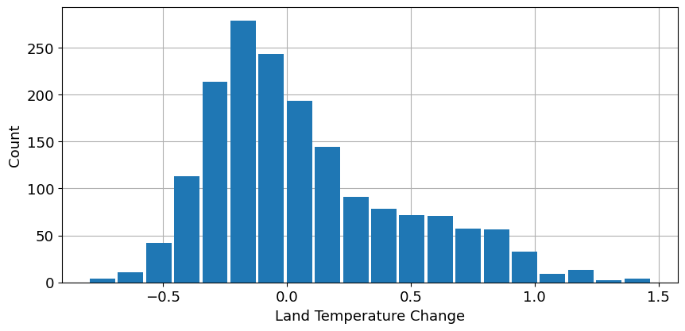

```python
ax = df_temperature["land"].hist(figsize=(10, 4.5), bins=20, zorder=3, rwidth=0.9)
ax.set_ylabel("Count")
ax.set_xlabel("Land Temperature Change");
```

It would be more useful to display this as a time series:

```python
# convenience function for time series plots
def create_ts_plot(data, title, ylabel, color="navy"):
    # create a time series plot
    ax = data.plot(figsize=(9, 4.3), legend=False, lw=2, zorder=3, color=color)
    plt.title(title, fontsize=fontsize-1)
    plt.ylabel(ylabel)
    plt.xlabel(None)
    ax.xaxis.grid(False)
    ax.yaxis.grid(True)
    return ax
```

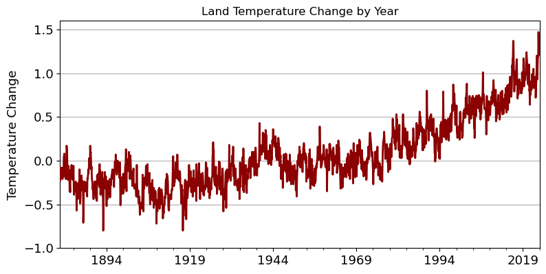

```python
ax = create_ts_plot(df_temperature["land"], "Land Temperature Change by Year",
               "Temperature Change", "darkred");
ax.set_ylim(-1, 1.6);
```

We could make this plot smoother by getting the 5 year rolling average:

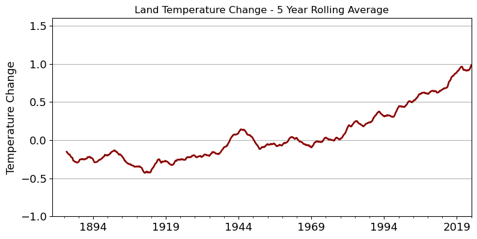

```python
# get the 5 year (i.e. 60 month) rolling average
df_temp_rolling = df_temperature["land"].rolling(60).mean()
ax = create_ts_plot(df_temp_rolling, "Land Temperature Change - 5 Year Rolling Average",
               "Temperature Change", "darkred");
ax.set_ylim(-1, 1.6);
```

From the data above we can see a step upward trend from the mid-1970s onwards.

Another way to visualise temperature change trends over time would be to look at comparisons between the distributions for different time periods, in a way that allows us to see outliers. A useful way to do this is with parallel box plots. We will do this for a number of recent decades.

```python
# extract data for a number of recent decades
df_recent = df_temperature[df_temperature.index.year >= 1960].copy()
# add a Decade column
df_recent['decade'] = (df_recent.index.year // 10) * 10
df_recent.head()
```

| date | land | station | decade |
| --- | --- | --- | --- |
| 1960-01-01 | 0.00 | 0.05 | 1960 |
| 1960-02-01 | 0.13 | 0.24 | 1960 |
| 1960-03-01 | -0.35 | -0.51 | 1960 |
| 1960-04-01 | -0.15 | -0.24 | 1960 |
| 1960-05-01 | -0.08 | -0.15 | 1960 |

Use the Seaborn package to create parallel box plots for the land temperature column:

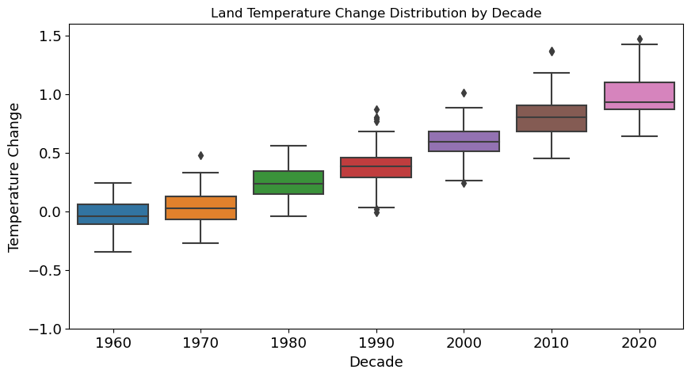

```python
plt.figure(figsize=(10, 5))
sns.boxplot(data=df_recent, x='decade', y='land')
plt.title("Land Temperature Change Distribution by Decade", fontsize=fontsize-1)
plt.xlabel("Decade")
plt.ylabel("Temperature Change");
plt.ylim(-1, 1.6);
```

The above gives us an indication of the distribution of the land temperatures per decade. We can see how the ranges are shifting upwards in each more recent decade.

### Analysis of Data for Individual Gases

Firstly, plot the recent seasonal Carbon Dioxide values (the "cycles"):

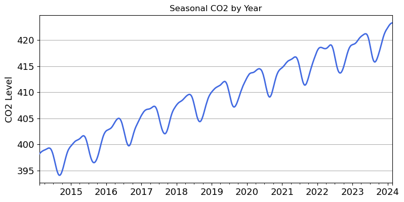

```python
create_ts_plot(dfg["co2"]["cycle"], "Seasonal CO2 by Year", "CO2 Level", "royalblue");
```

Next, plot the average amount of methane in the atmosphere per month:

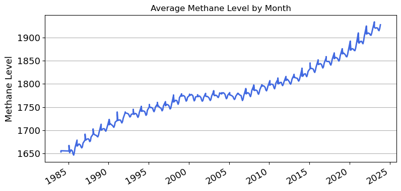

```python
create_ts_plot(dfg["methane"]["average"], "Average Methane Level by Month", "Methane Level", "royalblue");
```

For methane level, looking at a yearly average might make more sense:

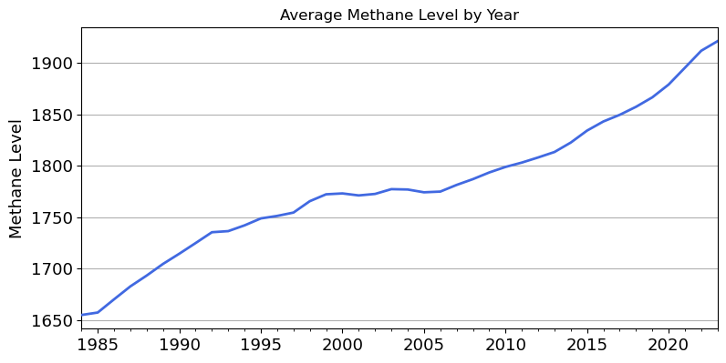

```python
df_methane_year = dfg["methane"]["average"].resample("1Y").mean()
create_ts_plot(df_methane_year, "Average Methane Level by Year",
               "Methane Level", "royalblue");
```

Again we see a steep upwards increase in the trend for methane emission levels since the mid-1980s.

Finally, we look at nitrous oxide levels over time, on a monthly basis:

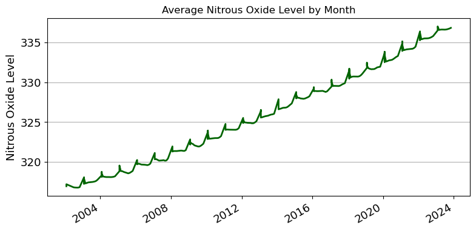

```python
create_ts_plot(dfg["nitrous-oxide"]["average"], "Average Nitrous Oxide Level by Month",
               "Nitrous Oxide Level", "darkgreen");
```

Again, the trend might be clearer if we visualise it by year, computing the mean across the year:

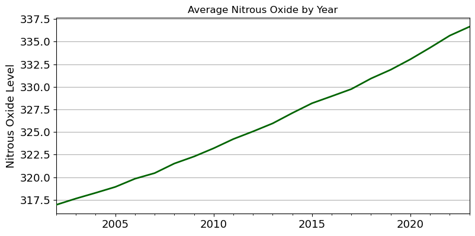

```python
df_no_year = dfg["nitrous-oxide"]["average"].resample("1Y").mean()
create_ts_plot(df_no_year, "Average Nitrous Oxide by Year",
               "Nitrous Oxide Level", "darkgreen");
```

Once, the levels of Nitrous Oxide in the atmosphere appear to be steadily increasing since the data was first collected.

### Temperature Change vs Gas Levels

Next, we will compare how temperature changes related to changes in the various gas levels.

First, we will convert our various variables into year formats.

```python
# get the mean per year
df_temp_year = df_temperature.resample("Y").mean()
# check the range
print("Temperature", format_range(df_temp_year))
df_temp_year.head(5)
```

```
Temperature 1880-12-31 to 2024-12-31
```

| date | land | station |
| --- | --- | --- |
| 1880-12-31 | -0.15 | -0.25 |
| 1881-12-31 | -0.08 | -0.19 |
| 1882-12-31 | -0.10 | -0.31 |
| 1883-12-31 | -0.16 | -0.29 |
| 1884-12-31 | -0.27 | -0.46 |

```python
dfg_year = {}
for gas in dfg:
    print("Resampling", gas)
    # get the mean per year
    dfg_year[gas] = dfg[gas].resample("Y").mean()
    # check the range
    print(format_range(dfg_year[gas]))
```

```
Resampling co2
2014-12-31 to 2024-12-31
Resampling methane
1984-12-31 to 2023-12-31
Resampling nitrous-oxide
2002-12-31 to 2023-12-31
```

From the above we can see that we have different date ranges for the data for each gas.

We have a very limited time range for CO2, so we will focus solely on methane and nitrous-oxide.

First we will look at methane, where we have the longest range of data. We compare for emissions for this gas and temperatures from the same era.

```python
# specify the date range based on the data we have
date_start = datetime(1985, 1, 1)
date_end = datetime(2023, 12, 31)
```

```python
# extract the data just for this range
dfm = dfg["methane"]
dfm = dfm[(dfm.index >= date_start) & (dfm.index <= date_end)]
# now convert the methane average values to years
dfm_years = dfm["average"].resample("1Y").mean()
dfm_years.head()
```

```
date
1985-12-31    1657.37
1986-12-31    1670.21
1987-12-31    1682.80
1988-12-31    1693.33
1989-12-31    1704.62
Freq: A-DEC, Name: average, dtype: float64
```

```python
# get temperature data for the same time range
dft = df_temperature[(df_temperature.index >= date_start) & (df_temperature.index <= date_end)]
# now convert the land temperature data to years
dft_years = dft["land"].resample("1Y").mean()
dft_years.head()
```

```
date
1985-12-31    0.12
1986-12-31    0.18
1987-12-31    0.32
1988-12-31    0.39
1989-12-31    0.27
Freq: A-DEC, Name: land, dtype: float64
```

```python
# merge the data into a single DataFrame
merged = {"methane" : dfm_years, "temperature": dft_years}
df_methane_merged = pd.DataFrame(merged)
df_methane_merged.head()
```

| date | methane | temperature |
| --- | --- | --- |
| 1985-12-31 | 1657.37 | 0.12 |
| 1986-12-31 | 1670.21 | 0.18 |
| 1987-12-31 | 1682.80 | 0.32 |
| 1988-12-31 | 1693.33 | 0.39 |
| 1989-12-31 | 1704.62 | 0.27 |

Now that we have methane levels and temperature in a single DataFrame, we can visualise the relationship between them using a scatter plot.

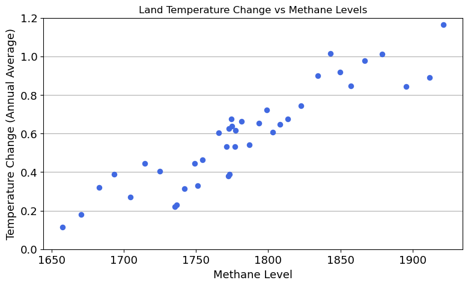

```python
ax = df_methane_merged.plot(kind="scatter", x="methane", y="temperature", figsize=(9, 5),
                            s=34, color="royalblue", zorder=3);
ax.xaxis.grid(False)
ax.yaxis.grid(True)
ax.set_ylim(0, 1.2)
ax.set_title("Land Temperature Change vs Methane Levels", fontsize=fontsize-1)
ax.set_xlabel("Methane Level")
ax.set_ylabel("Temperature Change (Annual Average)");
```

Instead of a visualisation, we could measure the overall correlation between methane levels and temperature. We see a strong correaltion:

```python
df_methane_merged.corr()
```

|  | methane | temperature |
| --- | --- | --- |
| methane | 1.00 | 0.92 |
| temperature | 0.92 | 1.00 |

We could apply a similar process to analyse the relationship between nitrous-oxide levels and temperature for recent years.

```python
# use a different time range
date_start = datetime(2003, 1, 1)
date_end = datetime(2023, 12, 31)
# extract the data just for this range
dfn = dfg["nitrous-oxide"]
dfn = dfn[(dfn.index >= date_start) & (dfn.index <= date_end)]
# now convert the methane average values to years
dfn_years = dfn["average"].resample("1Y").mean()
dfn_years.head()
```

```
date
2003-12-31    317.63
2004-12-31    318.26
2005-12-31    318.92
2006-12-31    319.83
2007-12-31    320.45
Freq: A-DEC, Name: average, dtype: float64
```

```python
# get temperature data for the same time range
dft = df_temperature[(df_temperature.index >= date_start) & (df_temperature.index <= date_end)]
# now convert the land temperature data to years
dft_years = dft["land"].resample("1Y").mean()
# merge the data into a single DataFrame
merged = {"no2" : dfn_years, "temperature": dft_years}
df_no2_merged = pd.DataFrame(merged)
df_no2_merged.head()
```

| date | no2 | temperature |
| --- | --- | --- |
| 2003-12-31 | 317.63 | 0.61 |
| 2004-12-31 | 318.26 | 0.53 |
| 2005-12-31 | 318.92 | 0.67 |
| 2006-12-31 | 319.83 | 0.64 |
| 2007-12-31 | 320.45 | 0.66 |

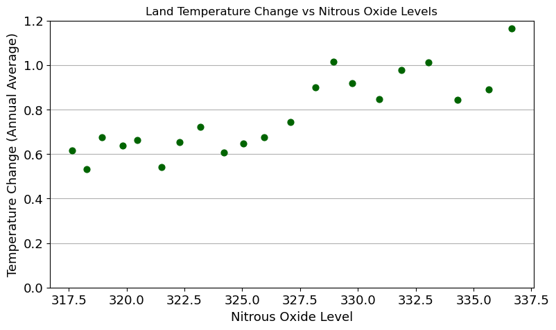

```python
ax = df_no2_merged.plot(kind="scatter", x="no2", y="temperature", figsize=(9, 5),
                            s=40, color="darkgreen", zorder=3);
ax.xaxis.grid(False)
ax.yaxis.grid(True)
ax.set_ylim(0, 1.2)
ax.set_title("Land Temperature Change vs Nitrous Oxide Levels", fontsize=fontsize-1)
ax.set_xlabel("Nitrous Oxide Level")
ax.set_ylabel("Temperature Change (Annual Average)");
```

The pattern above is a little less unclear, although this may be due to the shorter time range available for this measurement. However, we still see a high level of correlation between NO2 levels and temperature change:

```python
df_no2_merged.corr()
```

|  | no2 | temperature |
| --- | --- | --- |
| no2 | 1.00 | 0.86 |
| temperature | 0.86 | 1.00 |

## Conclusion

In this assignment we looked at the relationship between various greenhouse gases and land temperature changes. We see a strong correlation between these measures, with temperatures particularly trending upwards since the 1970s. However, one limitation is that we only have recent reliable data for gases such as CO2 and NO2. Further historic data might allow us to quanitfy the trends more reliably.

Further work could look at integrating ocean temperature change data from the API, while also looking at how temperature change is impact on polar ice cover. We could also conduct further analysis of the temperature change outliers and whether these events are become increasingly frequent in recent years.